# BST 267: Introduction to Social and Biological Networks (2022)

# Homework 1

### Question 1 (2 points)

Run the code below to generate a graph.

(a) What is the vertex set of this graph?

(b) What is the edge set of this graph?

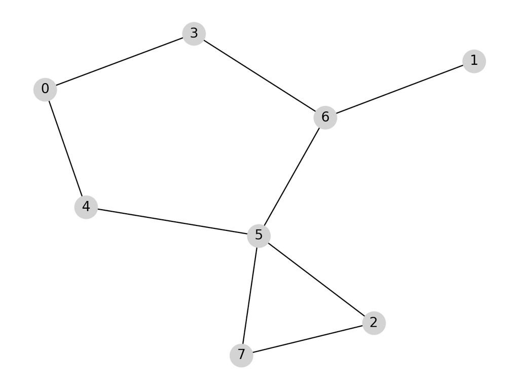

```python
# RUN THIS CODE (if you get  a warning and no output, try running it again)
import networkx as nx
import matplotlib.pyplot as plt
%matplotlib notebook

# generate a random graph realization
G = nx.erdos_renyi_graph(8, 0.4, seed=2022)

# visualize the graph using a commonly used layout algorithm
nx.draw_kamada_kawai(G, node_color="lightgray", node_size=400, with_labels=True)
```

**ANSWERS:**

(a) V={0, 1 ,2, 3, 4, 5, 6, 7}

(b) E = {(0,3), (0,4), (1,6), (2,5), (2,7), (3,6), (4,5), (5,6), (5,7)}

### Question 2 (2 points)

Run the code below to generate a graph.

(a) How many (connected) components are there? List the size of each component from largest to smallest. (Note that a component may have just one node.)

(b) If we select one of the nodes in this graph uniformly at random, what is the probability that the selected node belongs to the largest connected component?

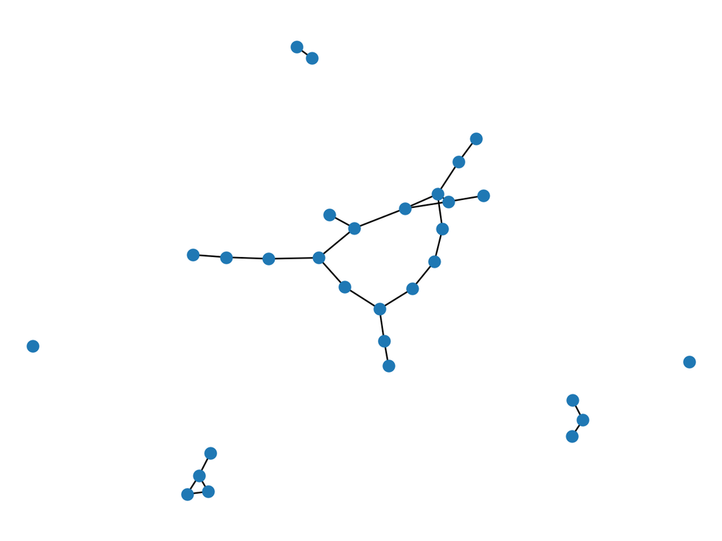

```python
# RUN THIS CODE
import networkx as nx
import matplotlib.pyplot as plt
%matplotlib notebook

# generate a random graph realization
G = nx.erdos_renyi_graph(30, 0.06, seed=2022)

# visualize the graph
plt.figure()
nx.draw(G, node_size=50)
```

**ANSWERS:**

(a)There are 6 (connected) components. List the size of each component from largest to smallest: 19, 4, 3, 2, 1, 1

(b) If we select one of the nodes in this graph uniformly at random, the probability that the selected node belongs to the largest connected component is 19/(4+3+2+1+1+19) = 0.633

```python
19/(4+3+2+1+1+19)
```

```
0.6333333333333333
```

### Question 3 (2 points)

Let's stay with the graph of Question 2 for a moment longer.

Consider a hypothetical spreading process on the network. We'll talk a lot more about spreading processes later in class, but one of the main ideas is that any spreading processes can only move along the edges of the graph. This means that if there is no path from node A to node B, the process cannot get from A to B or from B to A. We will assume in this question that if one node in a component gets infected, all nodes in the component will eventually get infected.

(a) One of the nodes in this graph, chosen uniformly at random, becomes infected. What is the probability that eventually more than half of the nodes in the graph become infected?

(b) One of the nodes in this graph, chosen uniformly at random, becomes infected. What is the probability that eventually at most 10% of all nodes become infected?

```python
0.1*30
```

```
3.0
```

```python
(1+1+2+3)/30
```

```
0.23333333333333334
```

**ANSWERS:**

(a) The probability that eventually more than half of the nodes in the graph become infected is 19/30 = 0.633

(b) The probability that eventually at most 10% of all nodes become infected is (1+1+2+3)/30 = 0.233

### Question 4 (2 points)

There is extensive documentation for Python online, and the online documentation for NetworkX is also robust. We will be using NetworkX in all assignments and labs, and we'll also cover the basics in class. The best way to learn is by doing. In this question we'll get started with the online NetworkX Tutorial available here: https://networkx.org/documentation/stable/tutorial.html#

Study the following sections of the tutorial: (1) Creating a graph, (2) Nodes, (3) Edges, (4) Examining elements of a graph, and (5) Removing elements from a graph. (Some of the language there may be somewhat technical, but for now you can ignore it.) **Using the methods and functions covered in these five sections**, add some Python code in the cell below to create a new graph `H` which has the same nodes and the same edges as the graph of Question 1. You can visualize the graph using the line of code provided.

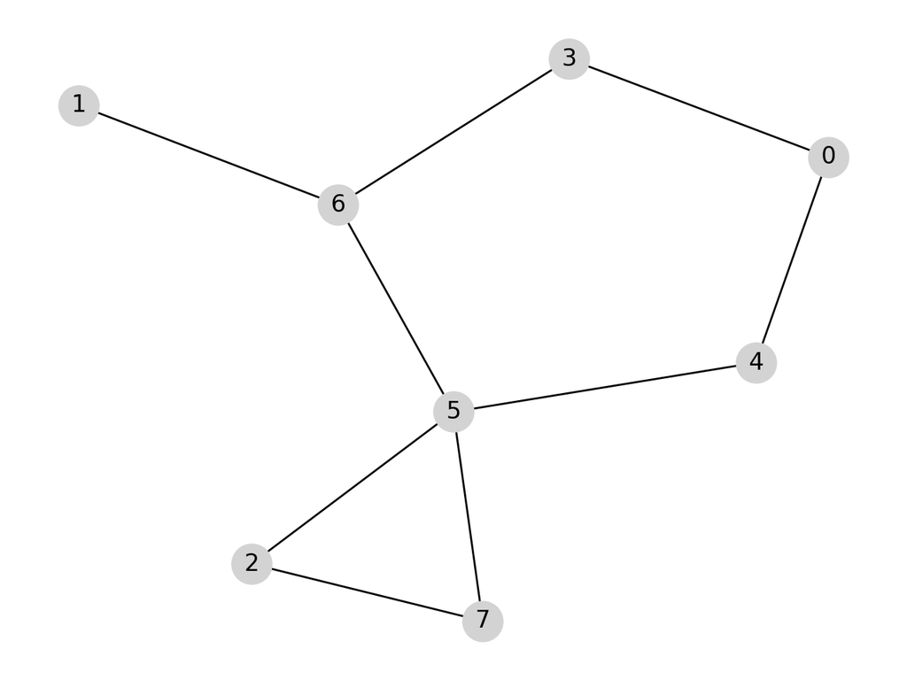

```python
# ADD YOUR CODE HERE
H =  nx.Graph()
# the same nodes #6
H.add_edges_from([(0,3), (0,4), (1,6), (2,5), (2,7), (3,6), (4,5), (5,6), (5,7)])
# the same edges

plt.figure()
# visualize the graph using a commonly used layout algorithm
nx.draw_kamada_kawai(H, node_color="lightgray", node_size=400, with_labels=True)
```